# Análise Exploratória - Malária

```r
# Pacotes transformação de dados
install.packages(c("tidyverse", "lubridate"))
```

[output not shown]

```r
# Pacotes plotagem
install.packages(c("geobr","sf","ggplot2","dplyr"))
```

[output not shown]

```r
library(scale)
```

[output not shown]

```r
library(tidyverse)
library(lubridate)
library(geobr)
library(sf)
library(ggplot2)
library(dplyr)
library(scales)
library(moments)
library(magrittr)
library(lubridate)
```

```r
# Carregamento de dts
load("malaria_2016.RData")
malaria_2016 <- data

load("malaria_2017.RData")
malaria_2017 <- data

load("malaria_2018.RData")
malaria_2018 <- data

load("malaria_2019.RData")
malaria_2019 <- data

ls()
```

```
 [1] "br_states"     "casos_tempo"   "centros"       "data"          "estado_resumo" "malaria"
 [7] "malaria_2016"  "malaria_2017"  "malaria_2018"  "malaria_2019"  "mapa"          "total_brasil"
```

[output not shown]

[output not shown]

```r
# Junção de dts
malaria <- bind_rows(
  malaria_2016,
  malaria_2017,
  malaria_2018,
  malaria_2019
)
```

```r
# Verificação dos dados
glimpse(malaria)
```

```
Rows: 6,391,535
Columns: 40
$ infection.county      <fct> 110001, 110001, 110001, 110001, 110001, 110001, 110001, 110002, 110002, 110002, 11…
$ home.county           <fct> 110001, 110001, 110001, 110001, 110012, 110001, 110001, 110002, 110020, 110002, 11…
$ notification.county   <fct> 110001, 110001, 110001, 110001, 110012, 110001, 110001, 110002, 110020, 110002, 11…
$ qty.parasites         <dbl> NA, NA, NA, 4, NA, NA, NA, NA, NA, 1000, 500, 1000, NA, NA, NA, 1000, 1000, NA, NA…
$ scheme                <fct> 1, 1, 1, 1, 1, 1, 1, NA, 99, 1, 1, 1, NA, NA, NA, 1, 1, NA, NA, NA, NA, NA, NA, 1,…
$ notification.hr       <fct> ZONA DA MATA, ZONA DA MATA, ZONA DA MATA, ZONA DA MATA, CENTRAL, ZONA DA MATA, ZON…
$ home.hr               <fct> ZONA DA MATA, ZONA DA MATA, ZONA DA MATA, ZONA DA MATA, CENTRAL, ZONA DA MATA, ZON…
$ infection.hr          <fct> ZONA DA MATA, ZONA DA MATA, ZONA DA MATA, ZONA DA MATA, ZONA DA MATA, ZONA DA MATA…
$ exam.type             <fct> thick and thin blood smears, thick and thin blood smears, thick and thin blood sme…
$ exam.result           <fct> vivax, vivax, vivax, vivax, vivax, vivax, vivax, negative, vivax, vivax, vivax, vi…
$ gender                <fct> male, female, female, female, male, male, female, female, female, male, female, fe…
$ hemiparasite          <fct> not researched, not researched, not researched, not researched, not researched, no…
$ symptom               <fct> yes, yes, yes, yes, yes, yes, yes, no, yes, yes, yes, yes, yes, yes, no, yes, yes,…
```

[output cut: 27 more lines]

[output not shown]

[output cut: 27 more lines]

[output not shown]

[output cut: 27 more lines]

```r
# Transformação de tipagem de colunas
malaria <- malaria %>%
  mutate(
    notification.month = as.numeric(as.character(notification.month)),
    notification.year = as.numeric(as.character(notification.year)),
    exam.month = as.numeric(as.character(exam.month)),
    exam.year = as.numeric(as.character(exam.year)),
    treatment.month = as.numeric(as.character(treatment.month)),
    treatment.year = as.numeric(as.character(treatment.year)),
    symptom.month = as.numeric(as.character(symptom.month)),
    symptom.year = as.numeric(as.character(symptom.year))
  )
```

```r
# Verificação de tipagem alterada
glimpse(malaria)
```

```
Rows: 6,391,535
Columns: 40
$ infection.county      <fct> 110001, 110001, 110001, 110001, 110001, 110001, 110001, 110002, 110002, 110002, 11…
$ home.county           <fct> 110001, 110001, 110001, 110001, 110012, 110001, 110001, 110002, 110020, 110002, 11…
$ notification.county   <fct> 110001, 110001, 110001, 110001, 110012, 110001, 110001, 110002, 110020, 110002, 11…
$ qty.parasites         <dbl> NA, NA, NA, 4, NA, NA, NA, NA, NA, 1000, 500, 1000, NA, NA, NA, 1000, 1000, NA, NA…
$ scheme                <fct> 1, 1, 1, 1, 1, 1, 1, NA, 99, 1, 1, 1, NA, NA, NA, 1, 1, NA, NA, NA, NA, NA, NA, 1,…
$ notification.hr       <fct> ZONA DA MATA, ZONA DA MATA, ZONA DA MATA, ZONA DA MATA, CENTRAL, ZONA DA MATA, ZON…
$ home.hr               <fct> ZONA DA MATA, ZONA DA MATA, ZONA DA MATA, ZONA DA MATA, CENTRAL, ZONA DA MATA, ZON…
$ infection.hr          <fct> ZONA DA MATA, ZONA DA MATA, ZONA DA MATA, ZONA DA MATA, ZONA DA MATA, ZONA DA MATA…
$ exam.type             <fct> thick and thin blood smears, thick and thin blood smears, thick and thin blood sme…
$ exam.result           <fct> vivax, vivax, vivax, vivax, vivax, vivax, vivax, negative, vivax, vivax, vivax, vi…
$ gender                <fct> male, female, female, female, male, male, female, female, female, male, female, fe…
$ hemiparasite          <fct> not researched, not researched, not researched, not researched, not researched, no…
$ symptom               <fct> yes, yes, yes, yes, yes, yes, yes, no, yes, yes, yes, yes, yes, yes, no, yes, yes,…
```

[output cut: 27 more lines]

[output not shown]

[output cut: 27 more lines]

[output not shown]

[output cut: 27 more lines]

```r
# Filtragem para dados dentro do escopo a ser analisado 2016-2019
malaria <- malaria %>%
  filter(notification.year >= 2016 & notification.year <= 2019)
```

```r
# Filtragem para dados somente no Brasil
malaria <- malaria %>%
  filter(infection.country == "Brazil")
```

```r
# Filtragem de linhas únicas
malaria <- malaria %>%
  distinct()
```

```r
# Criação de coluna data de notificação
malaria <- malaria %>%
  mutate(
    notification.date = as.Date(
      paste(notification.year, notification.month, "01", sep="-")
    )
  )
```

```r
# Análise de valores do campo exam.result
unique(malaria$exam.result)
```

```
 [1] vivax          negative       falciparum     non falciparum F+V            V+FG           F+FG
 [8] FG             F+M            malariae       <NA>
Levels: negative falciparum F+FG vivax F+V V+FG FG malariae F+M ovale non falciparum
```

[output not shown]

```r
# Criação de campo malaria.type
malaria <- malaria %>%
  mutate(
    malaria.type = case_when(
      exam.result == "negative" ~ "Negativo",
      exam.result == "vivax" ~ "Vivax",
      exam.result == "falciparum" ~ "Falciparum",
      TRUE ~ "Outros"
    )
  )
```

```r
# Cálculo de percentual de positivos no Brasil
total_brasil <- nrow(malaria)


estado_resumo <- malaria %>%
  mutate(
    positive = exam.result != "negative"
  ) %>%
  group_by(notification.state) %>%
  summarise(
    positivos = sum(positive, na.rm = TRUE)
  ) %>%
  mutate(percentual = positivos/total_brasil*100)
```

```r
br_states <- read_state()
```

[output not shown]

[output cut: 485 more lines]

[output not shown]

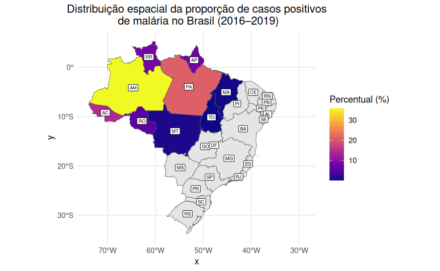

[figure not shown]

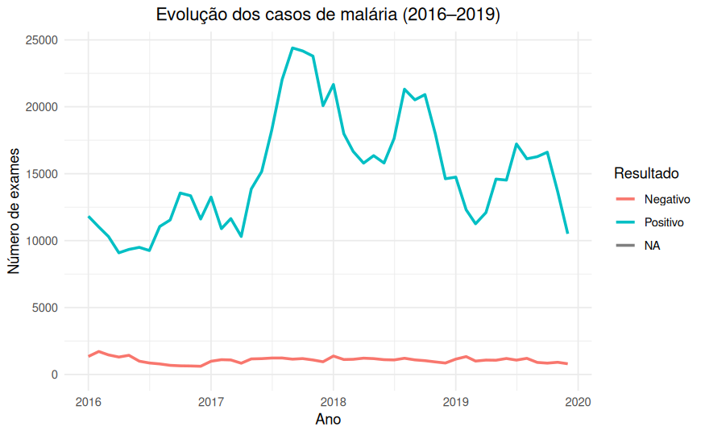

[figure not shown]

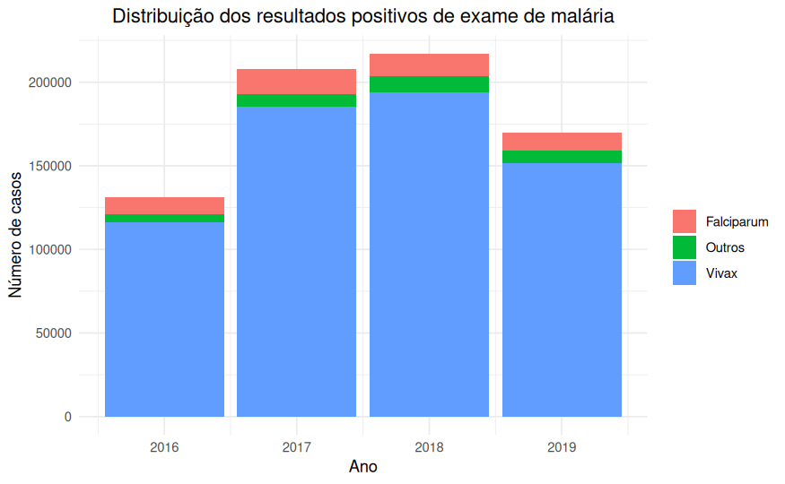

[figure not shown]

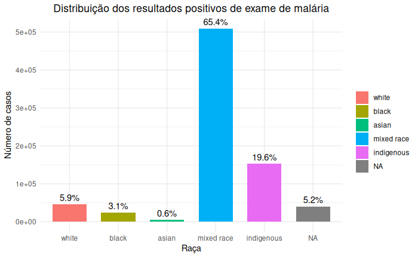

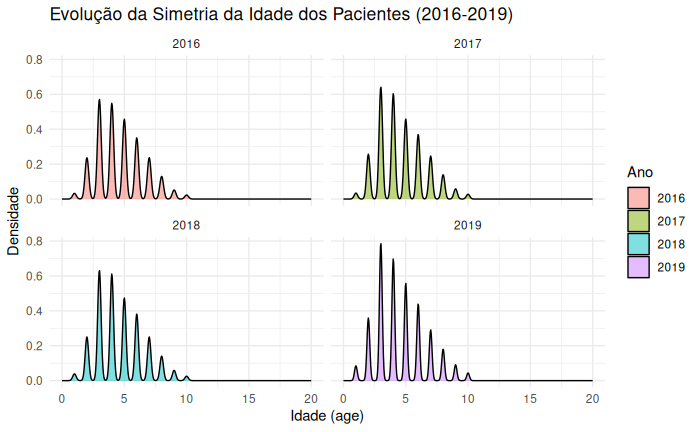